# STA 533 Homework 3

Melanie Miller

West Chester University

# 1 Introduction

The Penguins data set used consists of size measurements for adult foraging penguins in near Palmer Station, Antarctica. The information on the penguins includes several different size measurements, an island location in the Archipelago, sex, and in this analysis we will be looking at the flipper length and bill length. There are 8 variables and 344 observations.

# 2 Bill Length vs Flipper Length Scatter Plot

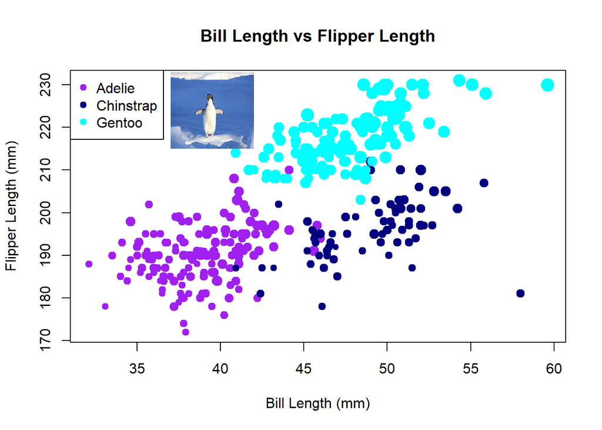

```r
data3<-read.csv(url("https://melaniemiller1.github.io/STA533/w03-HW/w03-penguins.csv"))

penguin.img <- "https://melaniemiller1.github.io/STA533/w03-HW/penguin.jpeg"
penguin <- readJPEG(getURLContent(penguin.img))
raster.penguin <- as.raster(penguin)


bill.length = data3$bill_length_mm
flipper.length = data3$flipper_length_mm
bodymass.size = data3$body_mass_g
species = data3$species

## identifying the ID
Adelie.id = which(data3$species=="Adelie")
Chinstrap.id = which(data3$species=="Chinstrap")
Gentoo.id = which(data3$species=="Gentoo")

## color code
 col.code = c(alpha("purple",0.5),alpha("navy",0.5),alpha("cyan",0.5))
## making an empty plot: type = "n" ==> no point

plot(bill.length, flipper.length, main = "Bill Length vs Flipper Length", type = "n",
     xlab="Bill Length (mm)", ylab="Flipper Length (mm)")

## change the point size based on their average of bill length and flipper length
points(bill.length[Adelie.id], flipper.length[Adelie.id],
       pch = 19, col = "purple", cex = bodymass.size[Adelie.id]/3000)
points(bill.length[Chinstrap.id], flipper.length[Chinstrap.id],
       pch = 19, col = "navy", cex = bodymass.size[Chinstrap.id]/3000)
points(bill.length[Gentoo.id], flipper.length[Gentoo.id],
       pch = 19, col = "cyan", cex = bodymass.size[Gentoo.id]/3000)
legend("topleft", c("Adelie", "Chinstrap", "Gentoo"),
                  col=c("purple", "navy", "cyan"),
                  pch=c(19, 19, 19))

#specify the position of the image through bottom-left and top-right coords
rasterImage(raster.penguin,37, 215,42,233)
```

Based on this scatter plot it is clear there are three obvious clusters of our different penguin species, the Adelie penguins tend to stay in the same region, the Chinstrap tend to stay in the same region, and the Gentoo tend to stay in the same region based on the relationship of their bill and flipper length. In other words, penguins of the same species are similar in size. Based on the plot and point sizes that are reflective of the penguin’s body mass, it is clear the Gentoo species tend to be larger than the others, while the Chinstrap and Adelie tend to be on the smaller side.